# The Gradient Problem

2026-01-29 · Shammah Chancellor

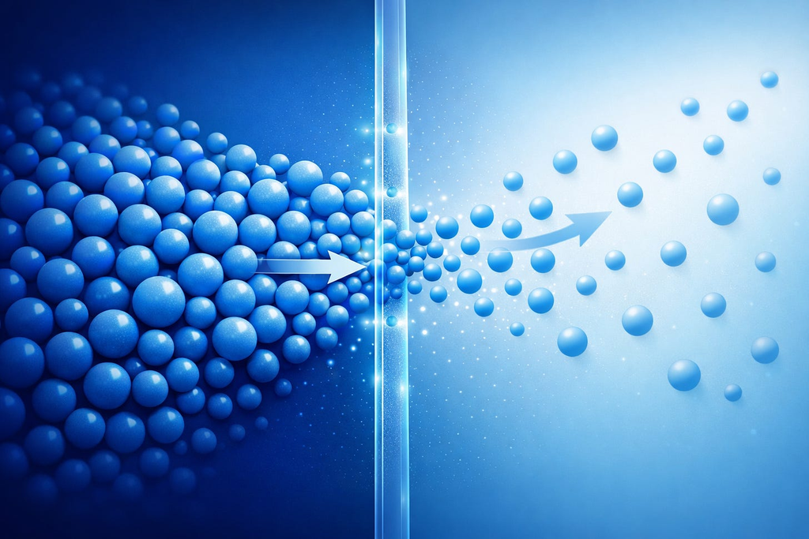

*“The greatest danger to a free people is not tyranny, but the slow erosion of the habits and institutions that make freedom possible.”*  
—**Alexis de Tocqueville**

## **A Fractured Moment**

Across much of the developed world, immigration has become the central political fault line.

In the United States, protests and riots surrounding immigration enforcement — particularly involving ICE — have escalated from episodic demonstrations into sustained unrest in some cities. In the United Kingdom and across parts of Europe, mass migration over a single generation has driven rising political polarization, street violence, and the rapid growth of parties once considered marginal. Governments appear unwilling or unable to respond decisively, oscillating between symbolic gestures, legal paralysis, and selective non-enforcement.

The result is a widening gap between public concern and institutional response. Trust erodes. Anger accumulates. Politics hardens.

What is striking is not only the intensity of the divide, but how poorly it is being explained.

On one side, critics reach for conspiracies — shadowy coordination by elites, NGOs, or foreign actors allegedly engineering demographic change. These narratives are emotionally satisfying. They assign blame. They offer villains.

They are also unnecessary.

What we are witnessing is not a plot. It is a systems failure.

*“There are no solutions. There are only trade-offs.”*  
—**Thomas Sowell**

## **Moral Premises**

Before discussing mechanisms or policy, a few moral premises should be stated plainly.

Every human life has equal inherent worth. This is not contingent on nationality, culture, intelligence, or circumstance. It is simply true.

It is also true that circumstances of birth exert a profound influence on life outcomes. Being born into a stable, wealthy society is a winning lottery ticket. Enormous human potential is lost simply because of where someone happens to be born. This is a real and enduring tragedy.

None of what follows is an argument against compassion or human dignity. It is an argument about *how* help is delivered, and about the moral obligation to evaluate outcomes rather than intentions alone.

Bad solutions make conditions worse — not only for host societies, but for the very people they are meant to help. Policies that feel compassionate in the moment can produce win-lose or even lose-lose outcomes: institutional erosion, dependency, social fragmentation, and a shrinking capacity to help anyone over time.

Moral reasoning that ignores counterfactuals is incomplete. The relevant question is not simply *what feels humane now*, but *what produces the least total harm and the greatest durable improvement in human flourishing over time*, compared to realistic alternatives.

There are no painless solutions. There are only tradeoffs. The task is to choose the least destructive ones.

*“Put on your own oxygen mask before assisting others.”*

## **The Life Vest Principle**

Flight attendants give the same instruction every time: put on your own oxygen mask before assisting others.

This is not selfishness. It is an acknowledgment of constraint.

A person who incapacitates themselves cannot help anyone else. A system that collapses under the weight of its own compassion loses the ability to provide aid at all.

Developed societies are complex, fragile systems built over generations. They depend on trust, institutional continuity, and social coordination. If those systems fail, the result is not greater justice, but fragmentation, conflict, and a sharp reduction in the capacity to help anyone — domestically or abroad.

Preserving internal civic order is not a rejection of compassion. It is the precondition for it.

*“People respond to incentives. The rest is commentary.”*  
—**Steven Landsburg**

## **Population Movement Without Villains**

Large-scale human migration does not require conspiracy, coordination, or malicious intent.

People move in response to gradients: safety, opportunity, stability, and population pressure. When disparities between regions are large, information about those disparities is widespread, and barriers are permeable, net movement is inevitable.

Welfare access, labor demand, and legal tolerance increase permeability. Modern communication technologies steepen gradients by making opportunity visible.

No centralized plan is required. The system runs on its own.

## **An Analogy from Physics: Chemical Potential**

In physics and chemistry, systems evolve toward equilibrium not because anything “wants” to happen, but because gradients create pressure.

Chemical potential formalizes this idea. When two regions are separated by a semi-permeable barrier, particles flow from higher potential to lower potential if passage is allowed.

Crucially, no motive force is required. A difference in density alone is sufficient. Even without added energy, coordination, or intent, net movement occurs simply because the imbalance exists.

Additional forces can accelerate movement, but they are not prerequisites. The gradient itself is enough.

As with all analogies, this one is imperfect — but it clarifies pressures and limits that moral narratives often obscure.

Human migration behaves in much the same way.

This matters because it shifts the debate from *who intended this* to *how systems behave when limits are ignored*.

## **Assimilation Is a Rate-Limited Process**

Assimilation is real, necessary, and it is not infinitely elastic.

Cultural integration depends on repeated interaction, shared norms, trust formation, and institutional reinforcement. These processes take time. When inflow rates are modest, assimilation can be gradual and largely successful. When inflow rates exceed certain thresholds, the dynamics change qualitatively.

Above those thresholds, self-association increases. Parallel institutions emerge. Trust declines. Civic identity thins. What was once a shared social fabric becomes fragmented.

This is not a moral failure. It is a rate problem.

## **Balkanization as an Emergent Outcome**

When assimilation limits are exceeded, balkanization is not chosen — it emerges.

Informal separation precedes formal separation. Parallel economies and governance structures develop. Over time, cultural distance hardens into political reality.

This process does not require animosity or ideology. It is an emergent property of scale, speed, and human social behavior.

Attempts to suppress these dynamics through moral exhortation alone do not stop them. They delay response until conditions are worse.

## **Moral Equality Does Not Imply Territorial Entitlement**

Moral equality governs how we treat people. Territorial sovereignty governs how societies persist.

Every human life has equal worth. This does not imply that every human has an equal claim to every territory, institution, or welfare system. These are categorically different concepts.

Land is finite. Institutions are fragile. Trust is cumulative. Societies inherit these across generations through law, language, and shared norms.

Confusing moral equality with unlimited territorial entitlement dissolves both. It renders borders meaningless and makes sustained cooperation impossible.

A society that cannot define and enforce its boundaries cannot maintain the institutions that make generosity possible.

## **The Real Failure: Incentives and Selective Non-Enforcement**

The current immigration crisis in Western nations is not primarily a border problem. It is an incentive problem.

In most developed countries today:

- Employers who knowingly hire illegal labor face minimal risk.
- Individuals and organizations that harbor undocumented migrants are rarely charged.
- Undocumented migrants routinely receive welfare benefits and public services designed for citizens and lawful residents.
- Enforcement focuses on expensive, individualized removals rather than upstream incentive correction.

This incentive structure is anti-nativist in effect — not because of explicit hostility to citizens, but because incentives systematically favor illegality over compliance. It penalizes compliance, subsidizes illegality, and shifts costs onto citizens while avoiding enforcement at the points where it would actually work.

A system that rewards rule-breaking and penalizes adherence cannot sustain legitimacy.

## **Lawful Enforcement, Not Moral Theater**

The necessary response is not mass roundups, raids, or spectacle. It is boring, consistent, lawful enforcement at the pressure points that shape behavior:

**1. Employer enforcement**  
Meaningful penalties for knowingly employing illegal labor.

**2. Harboring enforcement**  
Enforcement of existing laws against organized facilitation.

**3. Welfare eligibility enforcement**  
Restricting taxpayer-funded benefits to lawful residents who have paid into the system.

If these levers were enforced consistently, large-scale self-deportation would occur organically. When illegal residence no longer confers net benefit, most people do not stay.

This approach is cheaper, less chaotic, and more humane than chasing individuals through an overwhelmed bureaucracy.

What is radical is not enforcement. What is radical is maintaining a system where the law is openly violated at scale and the state refuses to act.

## **Cruelty, Injustice, and Tradeoffs**

Removing access to welfare or requiring people to return to their country of origin will worsen conditions for some. That is real. It is also unavoidable.

Cruelty, however, is not the same as injustice.

People who entered illegally, violated the law, and drew benefits from systems they were not entitled to are not owed permanent support by the societies they entered. Ending those benefits is harsh in effect, but not unjust in principle.

The choice is not between cruelty and kindness. It is between bounded cruelty now and unbounded cruelty later — manifesting as social collapse, political radicalization, and far harsher enforcement under crisis conditions.

Delay does not reduce harm. It compounds it.

## **Strong Borders and Restored Capacity**

Internal enforcement is incoherent without credible border control.

Internal enforcement without border control is futile — it reduces stock while new flow immediately replaces it. Border enforcement without correcting internal incentives is equally ineffective. The two are inseparable.

Credible borders mean predictable entry enforcement, rapid asylum adjudication, consistent denial where claims fail, and clear consequences that are applied uniformly.

A state that cannot control entry cannot enforce labor law, manage welfare, or maintain public consent. A state that tolerates permanent illegality teaches its citizens that law itself is optional.

Restoring control restores legitimacy.

*“Development is freedom.”*  
—**Amartya Sen**

## **Helping People Where They Are**

Rejecting unlimited migration does not imply indifference to human suffering.

The most effective way to reduce migration pressure is to improve conditions where people live. There is good systemic analysis of this [available](https://www.youtube.com/watch?v=LPjzfGChGlE).

Traditional aid often fails because it substitutes external support for local agency. Donated goods destroy local markets. Large NGOs create dependency.

By contrast, direct cash transfers, microgrants, and local capital formation consistently outperform traditional aid. Small amounts of capital force local problem-solving, supply-chain creation, and institutional learning.

Strong borders buy time. Development reduces gradients. Neither works alone.

*“The perfect is the enemy of the good.”*  
—**Voltaire**

## **Compassion That Endures**

Borders and development are not opposites. They are complements.

Lawful enforcement restores capacity. Incentive correction reduces illegality. Development reduces pressure.

Compassion without limits fails. Limits without compassion harden.

The refusal to enforce law is not mercy. It is abdication — and its costs are borne by everyone.